# Assignment 13: Text Mining

*How to do it?*:

- Open the Rmarkdown file of this assignment (link) in Rstudio.
- Right under each **question**, insert a code chunk (you can use the hotkey `Ctrl + Alt + I` to add a code chunk) and code the solution for the question.
- `Knit` the rmarkdown file (hotkey: `Ctrl + Alt + K`) to export an html.
- Publish the html file to your Githiub Page.

*Submission*: Submit the link on Github of the assignment to Canvas

Sample Codes

```r
# Used lines below to install various packages
## install.packages("tidytext")
## install.packages("wordcloud")
## install.packages("textdata")

# Unable to install textrecipes as it was removed from CRAN repository (as of 11/13)
## install.packages("textrecipes")

# Loading libraries
library(dplyr)
library(gganimate)
library(ggplot2)
library(tidyverse)
library(knitr)
library(tidytext)
library(wordcloud)
library(textdata)
```

### Netflix Data

**1.** Download the `netflix_titles` at this link. Create a century variable taking two values:

```
- '21' if the released_year is greater or equal to 2000, and

- '20' otherwise.
```

```r
# Reading in data
df <- read_csv("netflix_titles.csv")

df$century <- case_when(df$release_year >= 2000 ~ '21',
                        TRUE ~ '20')
```

**2. Word Frequency**

1. Convert the description to tokens, remove all the stop words. What are the top 10 frequent words of movies/TV Shows in the 20th century. Plot the bar chart of the frequency of these words.

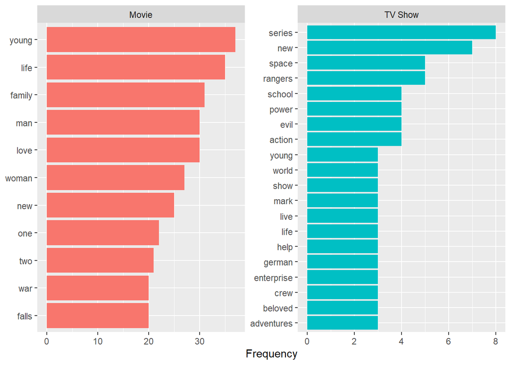

```r
df %>% filter(century == '20') %>%
  unnest_tokens(input = description, output = word) %>%
  anti_join(get_stopwords()) %>%
  count(type, word, sort = TRUE) %>%
  group_by(type) %>%
  slice_max(n, n=10) %>%
  ungroup() %>%
  mutate(word = reorder_within(word, by = n, within = type)) %>%
  ggplot(aes(n, word, fill = type)) +
  geom_col(show.legend = FALSE) +
  facet_wrap(~type, scales = "free") +
  labs(x = "Frequency",
       y = NULL) +
  scale_y_reordered()
```

2. What are the top 10 frequent words of movies/TV Shows in the 21st century. Plot the bar chart of the frequency of these words. Plot a side-by-side bar charts to compare the most frequent words by the two centuries.

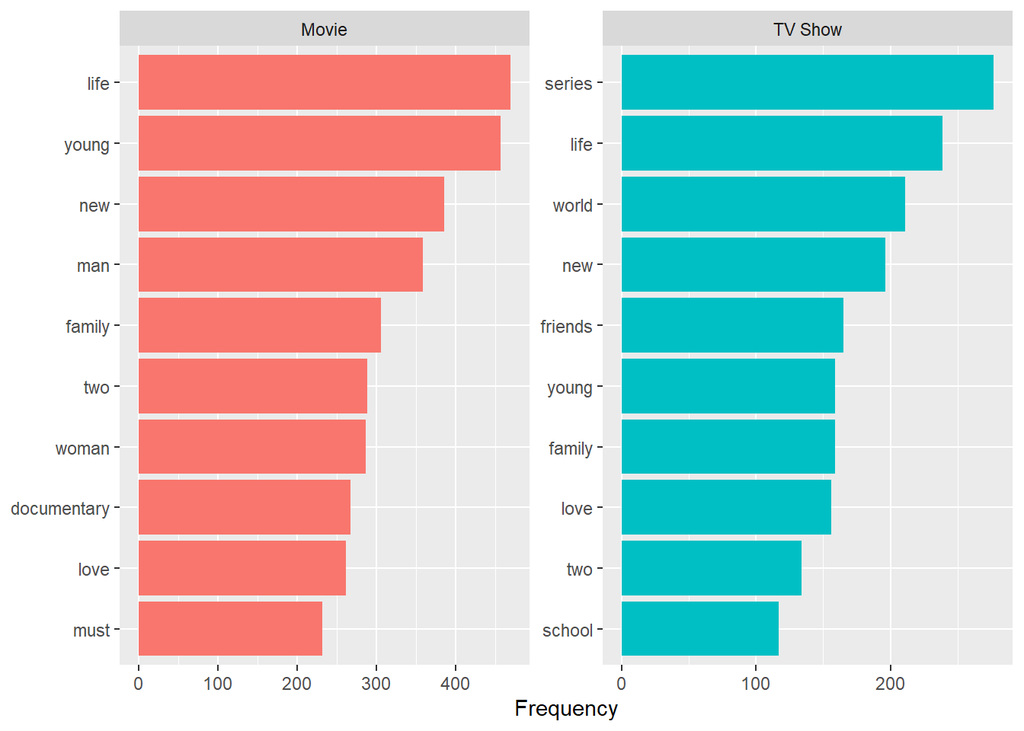

```r
df %>% filter(century == '21') %>%
  unnest_tokens(input = description, output = word) %>%
  anti_join(get_stopwords()) %>%
  count(type, word, sort = TRUE) %>%
  group_by(type) %>%
  slice_max(n, n=10) %>%
  ungroup() %>%
  mutate(word = reorder_within(word, by = n, within = type)) %>%
  ggplot(aes(n, word, fill = type)) +
  geom_col(show.legend = FALSE) +
  facet_wrap(~type, scales = "free") +
  labs(x = "Frequency",
       y = NULL) +
  scale_y_reordered()
```

**3. Word Cloud**

1. Plot the word cloud of the words in the descriptions in the movies/TV Shows in the 20th century.

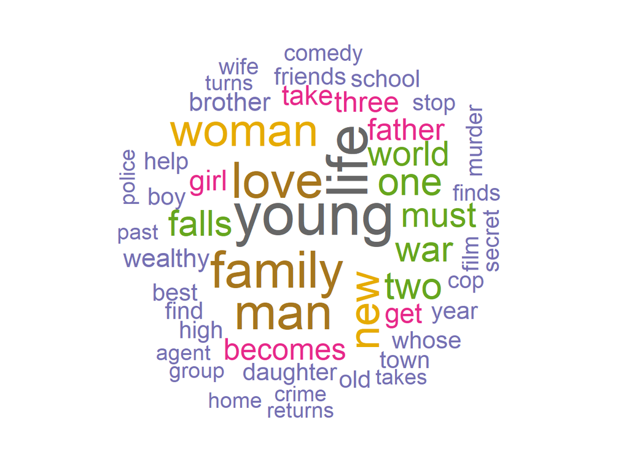

```r
colors <- brewer.pal(8,"Dark2")

df %>%
  filter(century == '20') %>%
  unnest_tokens(input = description, output = word) %>%
  anti_join(get_stopwords()) %>%
  count(type, word, sort = TRUE) %>%
  with(wordcloud(word, n, random.order = FALSE, max.words = 50, colors = colors))
```

2. Plot the word cloud of the words in the descriptions in the movies/TV Shows in the 21st century.

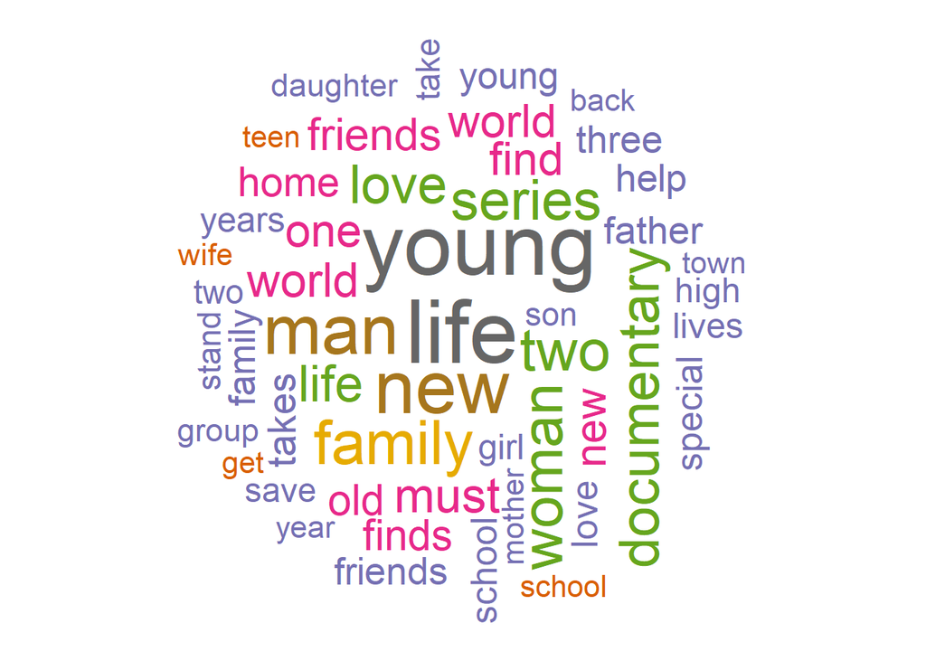

```r
df %>%
  filter(century == '21') %>%
  unnest_tokens(input = description, output = word) %>%
  anti_join(get_stopwords()) %>%
  count(type, word, sort = TRUE) %>%
  with(wordcloud(word, n, random.order = FALSE, max.words = 50, colors = colors))
```

**4. Sentiment Analysis**